# Second week: Introduction to R & Rstudio

Alaleh Ahmadian Shalchi

February 12, 2018

```r
library(dplyr)
library(ggplot2)
library(readr)

MobileData <- read_csv(file="c:/Users/Alaleh/Desktop/Term8/Data_Analysis/Data/mobile_data.csv")
```

## Problem 1

We need to find the companies with most phones made so we count phones which have the same company and make a new data frame cotaining company names and counts,

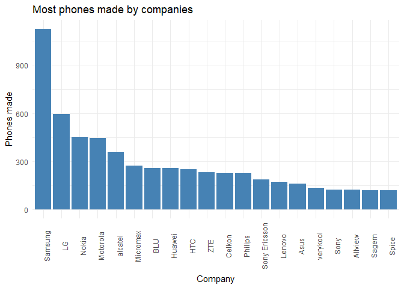

```r
MobileCounts = MobileData %>% group_by(company) %>% dplyr::summarise(counts = n()) %>% arrange(desc(counts))

Company_Count_Plot <- ggplot(data=head(MobileCounts,20), aes(x=reorder(company,-counts), y=counts)) + geom_bar(stat="identity", fill="steelblue") + theme_minimal() +  theme(axis.text.x = element_text(angle=90)) + labs(x="Company", y="Phones made", title="Most phones made by companies")
Company_Count_Plot
```

The plot shows that Samsung company has made far more phones than any other company which makes us wonder why that is…

```r
print(head(MobileCounts,1))
```

```
## # A tibble: 1 x 2
##   company counts
##     <chr>  <int>
## 1 Samsung   1127
```

Is it because their phones are better? have more diversity? are cheaper? easier to use? unfortunately we don’t have enought data to find out

## Problem 2

we make plots of all phones grouped by year and their dimensios and camera quality

```r
LengthMobileData <- data.frame("year" = MobileData$year,
                  "dim_length" = MobileData$dim_length)
LengthMobileData <- na.omit(LengthMobileData)

Lengths_Plot <- ggplot(LengthMobileData, aes(x=year, y=dim_length),) + geom_point(color="red")+ theme_minimal() +  theme(axis.text.x = element_text(angle=90)) + geom_smooth(method = "lm", se = FALSE) + labs(x="year", y="Phone Length", title="Length by year")

##########

BreadthMobileData <- data.frame("year" = MobileData$year,
                  "dim_breadth" = MobileData$dim_breadth)
BreadthMobileData <- na.omit(BreadthMobileData)

Breadth_Plot <- ggplot(BreadthMobileData, aes(x=year, y=dim_breadth),) + geom_point(color="blue")+ theme_minimal() +  theme(axis.text.x = element_text(angle=90)) + geom_smooth(method = "lm", se = FALSE) + labs(x="year", y="Phone breadth", title="Breadth by year")

##########


ThicknessMobileData <- data.frame("year" = MobileData$year,
                  "dim_thickness" = MobileData$dim_thickness)
ThicknessMobileData <- na.omit(ThicknessMobileData)

Thickness_Plot <- ggplot(ThicknessMobileData, aes(x=year, y=dim_thickness),) + geom_point(color="green")+ theme_minimal() +  theme(axis.text.x = element_text(angle=90)) + geom_smooth(method = "lm", se = FALSE) + labs(x="year", y="Phone thickness", title="Thickness by year")

##########


CameraMobileData <- data.frame("year" = MobileData$year,
                  "cam_px" = MobileData$cam_px)
CameraMobileData <- na.omit(CameraMobileData)

Camera_Plot <- ggplot(CameraMobileData, aes(x=year, y=cam_px),) + geom_point(color="brown")+ theme_minimal() +  theme(axis.text.x = element_text(angle=90)) + geom_smooth(method = "lm", se = FALSE) + labs(x="year", y="Camera quality(px)", title="Camera quality by year")
```

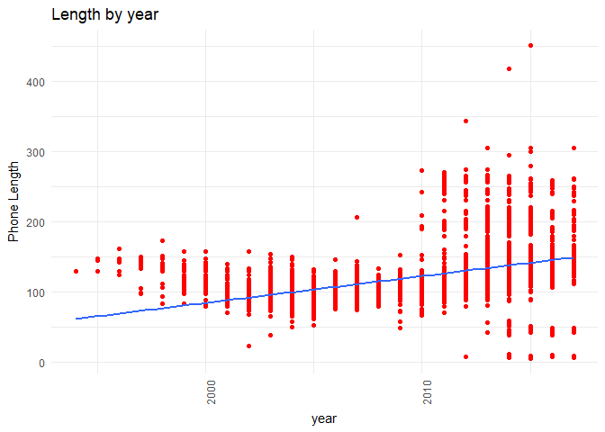

```r
Lengths_Plot
```

Since the beginning of 1990s until before the year 2005 the changes in phone lengths are descending, but since 2005 up to current times it takes an ascending turn. overall by this plot alone we don’t comprehend much but maybe putting it together with the next two plots we can understand something about the overall dimension of phones over time.

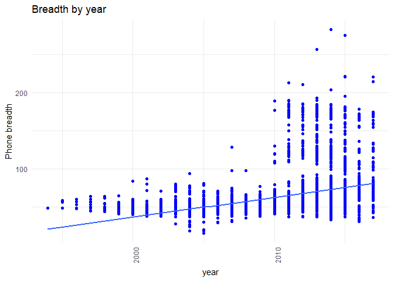

```r
Breadth_Plot
```

The plot shows that over time breadth of phones, made has take on an ascending approach.

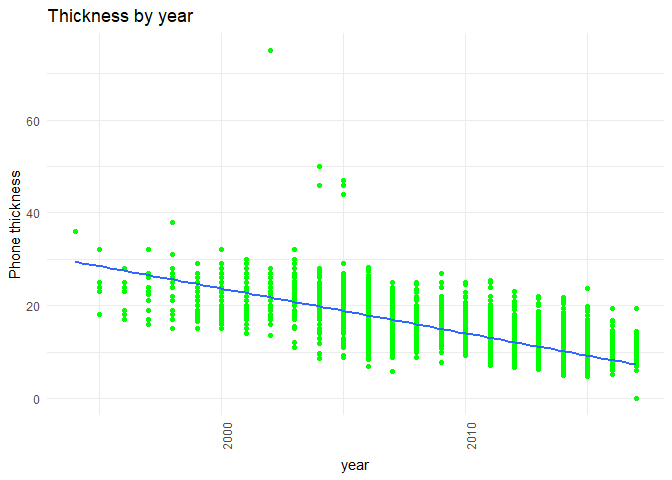

```r
Thickness_Plot
```

Throughout time the thickness of phones has descended

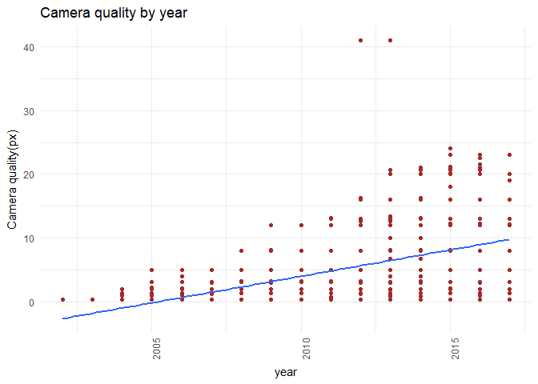

```r
Camera_Plot
```

The Data shows that phones didn’t have cameras up to the beginning of 2000s but after that implementing cameras became a normal thing and probably since the market probably responded well to cameras on phones and many people started to use phone cameras instead of home cameras, camera quality on phones got higher very fast.

The overall length is more than breadth and breadth is more than thickness which complies with the rectangualar thin picture of every cellphone Throughout time thickness has gotten even less but length and breadth has become more which shows that phones are getting bigger in display size.

## Problem 3

We group the data by number of simcards and LTE then calculate average of price of each group

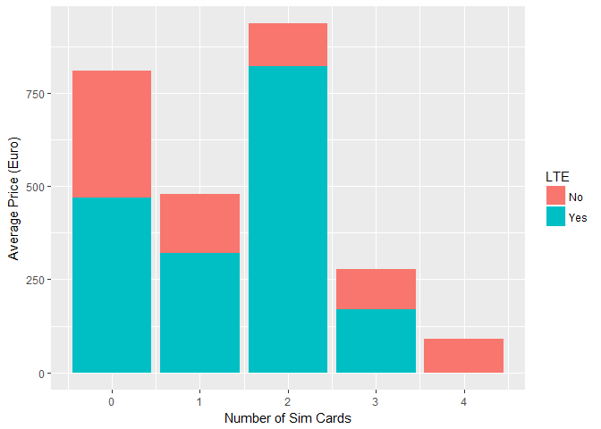

```r
mobilePrices = MobileData
mobilePrices %>% group_by(sim_no, LTE) %>% summarise(price=mean(price, na.rm = TRUE)) -> mobilePrices
PricePlot = ggplot(mobilePrices, aes(x=sim_no, y=price)) + geom_bar(stat = "identity", aes(fill=LTE)) + xlab("Number of Sim Cards") + ylab("Average Price (Euro)")

PricePlot
```

## Problem 4

We group the data by year, and then make a box plot for thickness of phones that have an audio jack vs. the ones that don’t

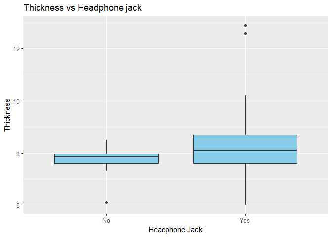

```r
MobilesOf2017 = MobileData[which(MobileData$year==2017),]
MobilesOf2017 = na.omit(MobilesOf2017)
PhoneBoxPlot = ggplot(MobilesOf2017, aes(audio_jack,dim_thickness)) + geom_boxplot(fill="skyblue") + labs(x='Headphone Jack', y='Thickness', title='Thickness vs Headphone jack')

PhoneBoxPlot
```

plot shows that phones with headphone jacks are slightly thicker which may be relevant to the jack

## Problem 5

Omitting NA Data we compute PPI for each phone by the formula sqrt(px_col^2 + px_row^2)/display_size

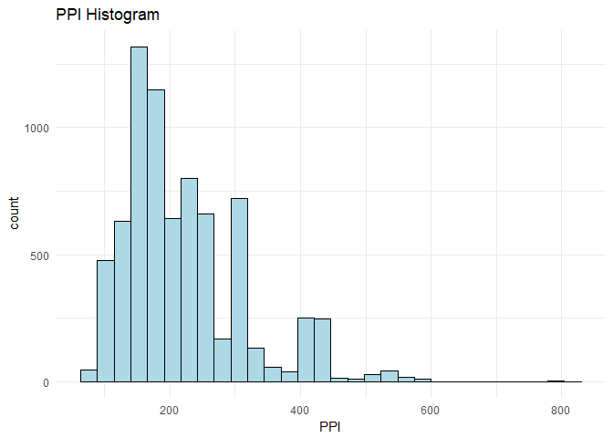

```r
PPI_Data = MobileData[,c('device','display_size','px_row','px_col','year')]
PPI_Data = na.omit(PPI_Data)
PPI_Data$PPI = sqrt(PPI_Data$px_row^2 + PPI_Data$px_col^2) / PPI_Data$display_size
PPI_Data %>% arrange(desc(PPI)) -> PPI_Data
PPI_Plot = ggplot(data = PPI_Data, aes(x=PPI)) + labs(title='PPI Histogram') + geom_histogram(color="black", fill="lightblue",) + theme_minimal()
PPI_Plot
```

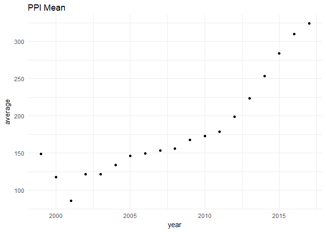

```r
PPI_Data %>% group_by(year) %>% summarise(average=mean(PPI)) -> Mean_PPI
Mean_PPI_Plot = ggplot(data = Mean_PPI, aes(x=year , y=average)) + geom_point()+ labs(title='PPI Mean') + theme_minimal()
Mean_PPI_Plot
```

Plot shows that PPI is ascending over time so phone display quality is rising

```r
  print(head(PPI_Data,1))
```

```
## # A tibble: 1 x 6
##              device display_size px_row px_col  year      PPI
##               <chr>        <dbl>  <int>  <int> <int>    <dbl>
## 1 Xperia XZ Premium         5.46   3840   2160  2017 806.9257
```

## Problem 6

p.s. trying this on all data gives many tablets which aren’t actually phones to be called gooshtkoob, so I removed any device with display_size>7 to get only phones

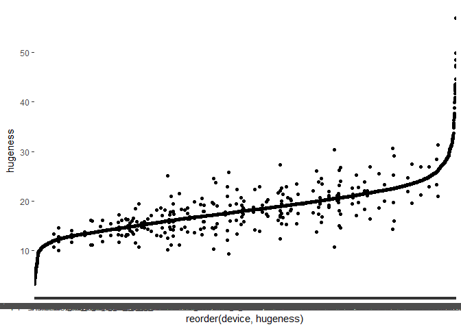

```r
FullMobileData <- data.frame("device" = MobileData$device,
                  "company" = MobileData$company,
                  "weight" = MobileData$weight,
                  "dim_breadth" = MobileData$dim_breadth,
                  "dim_length" = MobileData$dim_length,
                  "dim_thickness" = MobileData$dim_thickness,
                  "display_size" = MobileData$display_size)

FullMobileData = FullMobileData[which(FullMobileData$display_size<7),]
FullMobileData <- na.omit(FullMobileData)

FullMobileData$weight = 30*FullMobileData$weight/max(FullMobileData$weight)
FullMobileData$volume = FullMobileData$dim_breadth*FullMobileData$dim_length*FullMobileData$dim_thickness
FullMobileData$volume = 30*FullMobileData$volume/max(FullMobileData$volume)
FullMobileData$hugeness = FullMobileData$volume + FullMobileData$weight

ggplot(FullMobileData, aes(x=reorder(device, hugeness),y=hugeness)) + geom_point()
```

```r
head(FullMobileData[order(FullMobileData$hugeness, decreasing= T),c("device","company","hugeness")], n = 10)
```

```
##                  device   company hugeness
## 4356               MC55  Motorola 56.88000
## 2255    Advantage X7510       HTC 49.79798
## 2266    Advantage X7500       HTC 48.51798
## 2565             JASJAR    i-mate 47.34930
## 1725         Energy 400 Energizer 47.02775
## 1724         Energy 500 Energizer 44.62867
## 2779       DuraForce XD   Kyocera 43.57725
## 5959               9000      Qtek 43.43198
## 2001         7 VoiceTab        HP 43.41085
## 5144 9110i Communicator     Nokia 42.91943
```

## Problem 7

We compute density for each phone (not considering the empty air space inside them) and we sort all the phones by density. any phone under density=0.001 line, stays on water

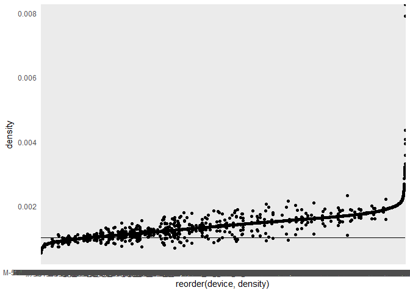

```r
FullMobileData <- data.frame("device" = MobileData$device,
                  "company" = MobileData$company,
                  "weight" = MobileData$weight,
                  "dim_breadth" = MobileData$dim_breadth,
                  "dim_length" = MobileData$dim_length,
                  "dim_thickness" = MobileData$dim_thickness)

FullMobileData <- na.omit(FullMobileData)

FullMobileData$density = FullMobileData$weight/(FullMobileData$dim_breadth * FullMobileData$dim_length * FullMobileData$dim_thickness)
FullMobileData = FullMobileData[with(FullMobileData, order(density)),]

DensityData = ggplot(FullMobileData, aes(x=reorder(device, density),y=density)) + geom_point() + theme_minimal() +
    geom_hline(yintercept = 0.001)

DensityData
```

we removed all the Null data from our data frame so they won’t mess with our conclusions.

Number of phones that won’t drown:

```r
undrowned_phones = filter(FullMobileData, density<0.001)
print(nrow(undrowned_phones))
```

```
## [1] 1014
```

Data for phones that don’t drown:

```r
print(undrowned_phones[c("device","company","density")])
```

[output not shown]

[output cut: 1000 more lines]

## Problem 8

We remove NA data so they won’t mess with calculations, and plot battery/weight plot

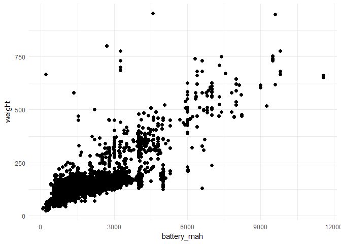

```r
FullMobileData <- data.frame("device" = MobileData$device,
                  "company" = MobileData$company,
                  "weight" = MobileData$weight,
                  "battery_mah" = MobileData$battery_mah)

FullMobileData <- na.omit(FullMobileData)

ggplot(FullMobileData, aes(battery_mah, weight)) +
  geom_point(shape = 16, size = 2) +
  theme_minimal()
```

```r
library(ggpubr)
cor(FullMobileData$battery_mah, FullMobileData$weight, method = "pearson")
```

```
## [1] 0.8086273
```

```r
cor.test(FullMobileData$battery_mah, FullMobileData$weight, method="pearson")
```

```
##
##  Pearson's product-moment correlation
##
## data:  FullMobileData$battery_mah and FullMobileData$weight
## t = 114.55, df = 6946, p-value < 2.2e-16
## alternative hypothesis: true correlation is not equal to 0
## 95 percent confidence interval:
##  0.8003307 0.8166142
## sample estimates:
##       cor
## 0.8086273
```

## Problem 9

Flagship has no definite meaning, the closest we found is the most expensive phones a company makes over time.

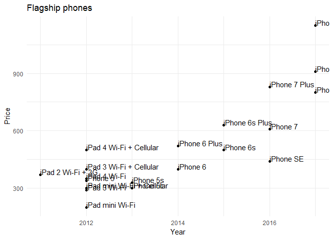

```r
Flagships <- subset(MobileData, company=="Apple")
Flagships = na.omit(Flagships)
Flagships <- Flagships[order(-Flagships$price),]

Flagship_Plot <- ggplot(data=head(Flagships,20), aes(x=year, y=price)) + geom_point() + theme_minimal() + labs(y="Price", x="Year", title="Flagship phones") + geom_text(aes(label=device),hjust=0, vjust=0)
Flagship_Plot
```

## Problem 10

For the first interesting plot I chose to find average ram to price ratio for each phone which shows over time what changes have been made to ram and price. since RAM has a small value, to get a better understanding of data and the ratio we multiply it by 100

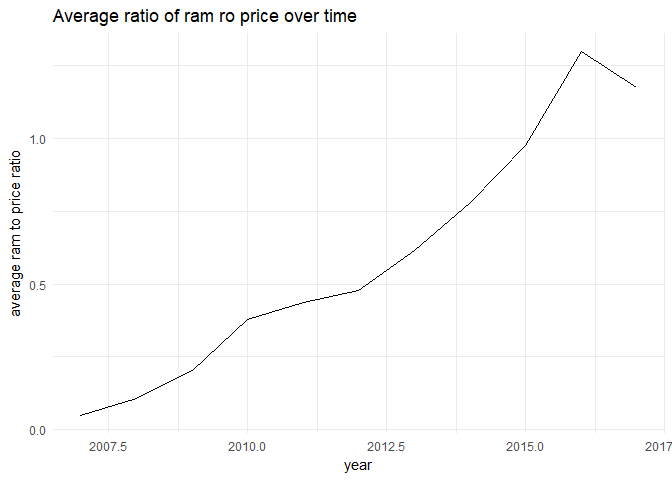

```r
MobileDatarm = na.omit(MobileData)
MobileDatarm$ram_price_ratio = MobileDatarm$ram*100/MobileDatarm$price
MobileDatarm %>% group_by(year) %>% summarise(average = mean(ram_price_ratio)) -> MobileDatarm

CamerasPlot <- ggplot(MobileDatarm, aes(x=year, y=average)) + geom_line(stat = "identity") + theme_minimal() + labs(x="year", y="average ram to price ratio", title="Average ratio of ram ro price over time")
CamerasPlot
```

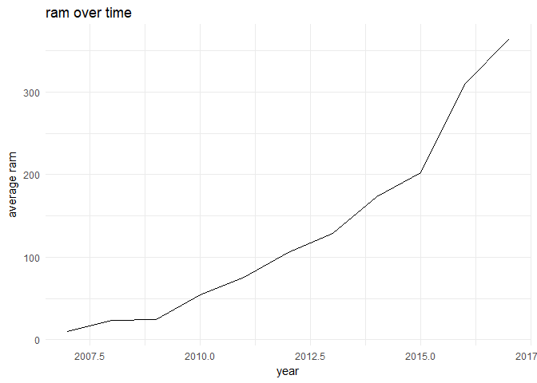

```r
ramDatarm = na.omit(MobileData)
ramDatarm %>% group_by(year) %>% summarise(average = mean(ram*100)) -> ramDatarm

ramPlot <- ggplot(ramDatarm, aes(x=year, y=average)) + geom_line(stat = "identity") + theme_minimal() + labs(x="year", y="average ram", title="ram over time")
ramPlot
```

RAM has been getting more and more in phones which makes sense since smart phones are getiing stronger every day

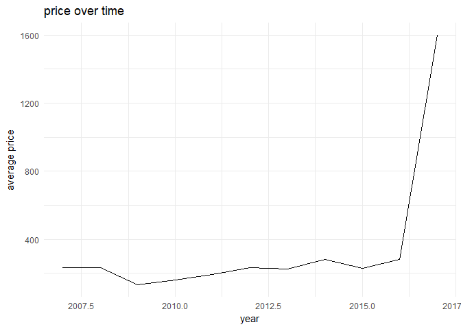

```r
priceDatarm = na.omit(MobileData)
priceDatarm %>% group_by(year) %>% summarise(average = mean(price)) -> priceDatarm

pricePlot <- ggplot(priceDatarm, aes(x=year, y=average)) + geom_line(stat = "identity") + theme_minimal() + labs(x="year", y="average price", title="price over time")
pricePlot
```

Phone prices seems to have been very steady over a period of 7 years but since 2016 to 2017 it has quickly raised a lot which explains the fall in the first plot.

For the second interesting plot I chose to find battery power of phones that have a built-in gpu since I suppose they must have a strong battery cause GPUs use a lot of power

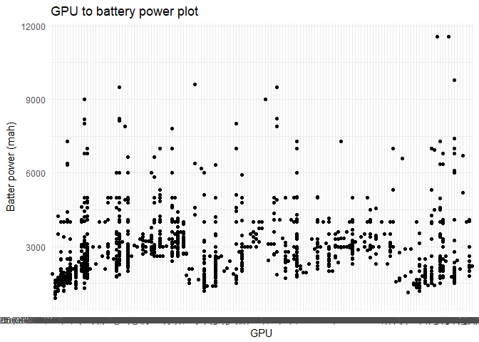

```r
GPUDatarm = na.omit(MobileData)

GPUPlot <- ggplot(GPUDatarm, aes(x=gpu, y=battery_mah)) + geom_point() + theme_minimal() + labs(x="GPU", y="Batter power (mah)", title="GPU to battery power plot")
GPUPlot
```

Contrary to what I though most of phones with GPUs don’t use very powerful batteries which may lead to them having to change batteries soon.

For the third interesting plot I chose find row to column ratio of phones to see whether they’re getting wider or not because i feel like it’s getting harder to fit phones on our hands lately

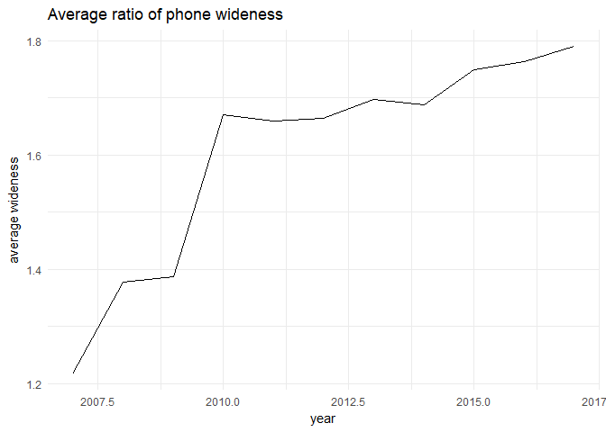

```r
widenessDatarm = na.omit(MobileData)
widenessDatarm$wideness_ratio = widenessDatarm$px_col/widenessDatarm$px_row
widenessDatarm %>% group_by(year) %>% summarise(average = mean(wideness_ratio)) -> widenessDatarm

widenessPlot <- ggplot(widenessDatarm, aes(x=year, y=average)) + geom_line(stat = "identity") + theme_minimal() + labs(x="year", y="average wideness", title="Average ratio of phone wideness")
widenessPlot
```

so overall phone displays (and phones themselves) are getting wider